# Differential analysis

# **Metadata**

Analysis

| R-Analysis Version | 2.11 |
| --- | --- |
| File | D:_portable\4.2.0-Portable_with_QP-proteomics-DA_proteins_set.txt |
| Number of rows | 2936 |
| Origin File |  |
| Date | 26-11-13 11:04:53 |

Experimental design

| File | repBio | Condition |
| --- | --- | --- |
| Intensity_10amol_1 | inj1 | 10amol |
| Intensity_10amol_2 | inj2 | 10amol |
| Intensity_10amol_3 | inj3 | 10amol |
| Intensity_10amol_4 | inj4 | 10amol |
| Intensity_50amol_1 | inj1 | 50amol |
| Intensity_50amol_3 | inj3 | 50amol |
| Intensity_50amol_2 | inj2 | 50amol |
| Intensity_50amol_4 | inj4 | 50amol |
| Intensity_100amol_1 | inj1 | 100amol |
| Intensity_100amol_3 | inj3 | 100amol |
| Intensity_100amol_2 | inj2 | 100amol |
| Intensity_100amol_4 | inj4 | 100amol |
| Intensity_250amol_1 | inj1 | 250amol |
| Intensity_250amol_2 | inj2 | 250amol |
| Intensity_250amol_3 | inj3 | 250amol |
| Intensity_250amol_4 | inj4 | 250amol |
| Intensity_500amol_1 | inj1 | 500amol |
| Intensity_500amol_3 | inj3 | 500amol |
| Intensity_500amol_2 | inj2 | 500amol |
| Intensity_500amol_4 | inj4 | 500amol |
| Intensity_1fmol_1 | inj1 | 1fmol |
| Intensity_1fmol_2 | inj2 | 1fmol |
| Intensity_1fmol_3 | inj3 | 1fmol |
| Intensity_1fmol_4 | inj4 | 1fmol |
| Intensity_5fmol_1 | inj1 | 5fmol |
| Intensity_5fmol_3 | inj3 | 5fmol |
| Intensity_5fmol_2 | inj2 | 5fmol |
| Intensity_5fmol_4 | inj4 | 5fmol |
| Intensity_10fmol_1 | inj1 | 10fmol |
| Intensity_10fmol_2 | inj2 | 10fmol |
| Intensity_10fmol_3 | inj3 | 10fmol |
| Intensity_10fmol_4 | inj4 | 10fmol |
| Intensity_25fmol_1 | inj1 | 25fmol |
| Intensity_25fmol_2 | inj2 | 25fmol |
| Intensity_25fmol_3 | inj3 | 25fmol |
| Intensity_25fmol_4 | inj4 | 25fmol |
| Intensity_50fmol_1 | inj1 | 50fmol |
| Intensity_50fmol_2 | inj2 | 50fmol |
| Intensity_50fmol_3 | inj3 | 50fmol |
| Intensity_50fmol_4 | inj4 | 50fmol |

Parameters

| Normalization | T |
| --- | --- |
| Proteins.for.normalization |  |
| Filter.threshold.ms | 2 |
| Filter.threshold.obs | 0.5 |
| No.imputed.values | F |
| Imputation.MNAR.model | gaussian |
| Imputation.MNAR.percentile | 5 |
| Imputation.MNAR.max.obs | 1 |
| Imputation.MCAR.model | none |
| Imputation.MCAR.min.obs | 3 |
| Imputation.MCAR.min.MSMS | 3 |
| Imputation.MCAR.intensity.cutoff | auto |
| Imputation.knn.min.occurrences | 3 |
| Test.type | t.test |
| Test.log | TRUE |
| Test.alternative | two.sided |
| Test.paired | FALSE |
| Test.var.equal | TRUE |
| Test.adjust.procedure | BH |
| Stat.threshold.significance | 0.05 |
| Stat.threshold.fc | 0.58 |
| Volcano.color.style | signifigance |
| Volcano.manual.accession |  |
| Volcano.no.labeling | F |
| Comparisons | 50fmol/25fmol;50fmol/500amol |
| Figure.format | PNG |
| Color.by.group | T |

# **Global Data filtering**

Filtered Proteins

| Filter | Value | Value_Percentage |
| --- | --- | --- |
| No specific peptides | 14 | 0.5 |
| Less than 50% observations in at least one group | 8 | 0.3 |
| Less than 2 files identified by MS/MS | 94 | 3.2 |
| Proteins kept for analysis | 2820 | 96.0 |

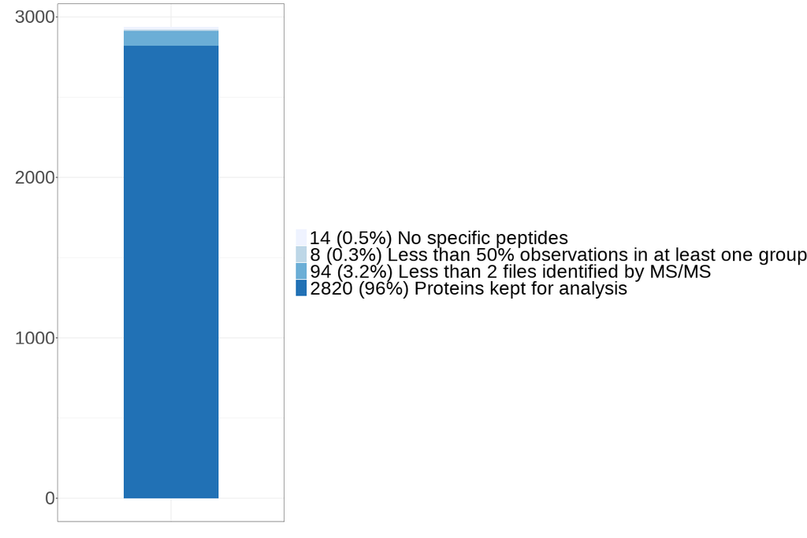

Save figure

# **Normalization**

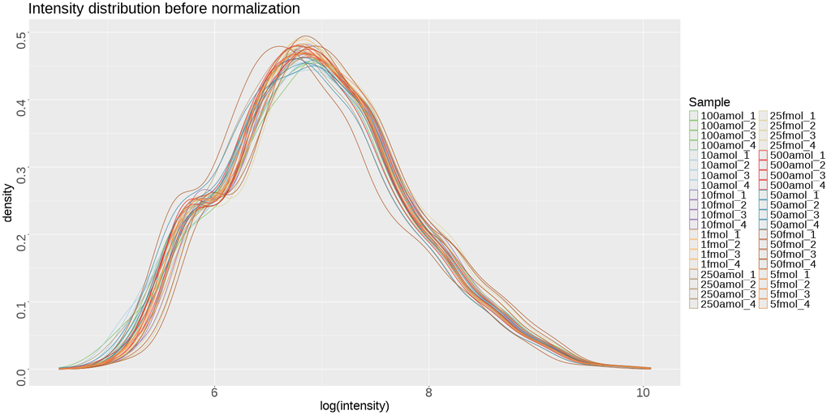

Save figure

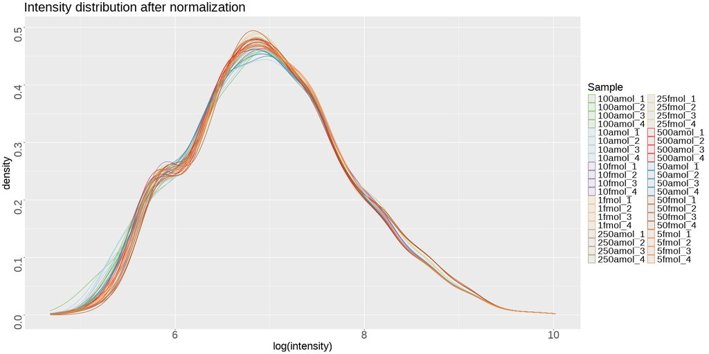

Save figure

Normalization method : each sample is divided by the median of its ratios to a reference sample (equivalently, the median log2 ratio is subtracted on the log2 scale). The reference is the sample with the lowest number of missing values (Intensity_1fmol_3). The medians were computed on 2820 proteins kept for the analysis. Normalization factors range from 0.579 to 1.141.

# **Missing values imputation**

Distribution of NA values across groups

| Group | NA_percentage | na_count |
| --- | --- | --- |
| 10amol | 7.271798 | 854 |
| 50amol | 6.888624 | 809 |
| 100amol | 6.590599 | 774 |
| 250amol | 6.692779 | 786 |
| 500amol | 5.960490 | 700 |
| 1fmol | 5.994550 | 704 |
| 5fmol | 5.951975 | 699 |
| 10fmol | 5.977520 | 702 |
| 25fmol | 6.854564 | 805 |
| 50fmol | 7.322888 | 860 |
| All groups | 6.550579 | 7693 |

Distribution of NA values across median intensities

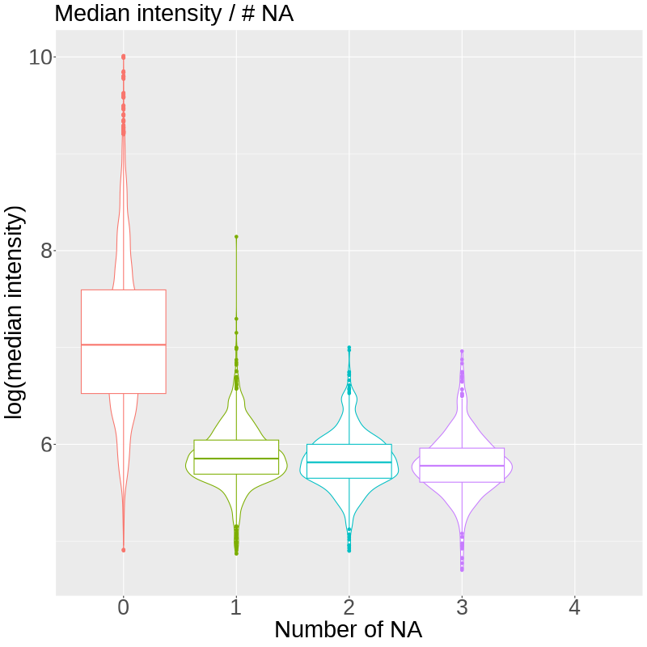

Save figure

Imputed values distribution

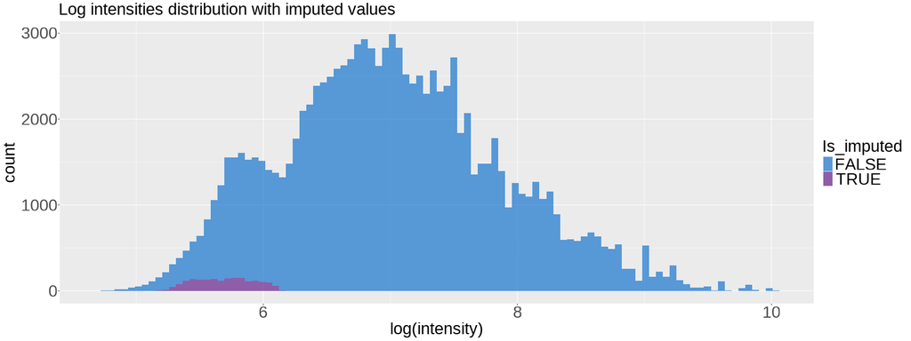

Save figure

Missing values of the 2820 proteins kept for the analysis were imputed with the noise model. The noise level of each sample is the 5% percentile of its observed intensities (log10: 5.57 to 5.79). For each protein and condition with missing values, values are drawn around these levels with a standard deviation of 0.82 log2 (0.25 log10), estimated within conditions on 6564 low-intensity protein/condition measurements. The imputation uses a fixed seed and is reproducible.

Missing values of the proteins kept for the analysis: 4606. MNAR (at most 1 observed value(s) in the condition), imputed with the background noise: 1837. Left missing (tests on the observed values only): 2769.

# **CV distribution**

Median deviation

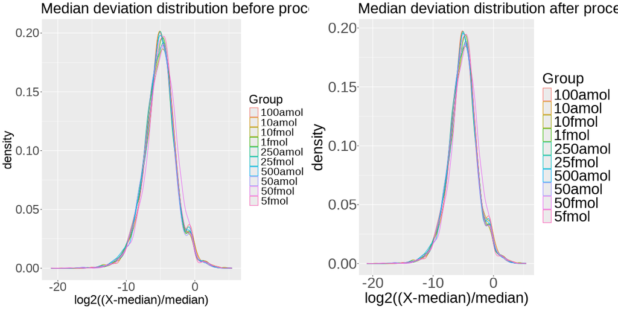

Save figure

CV distribution

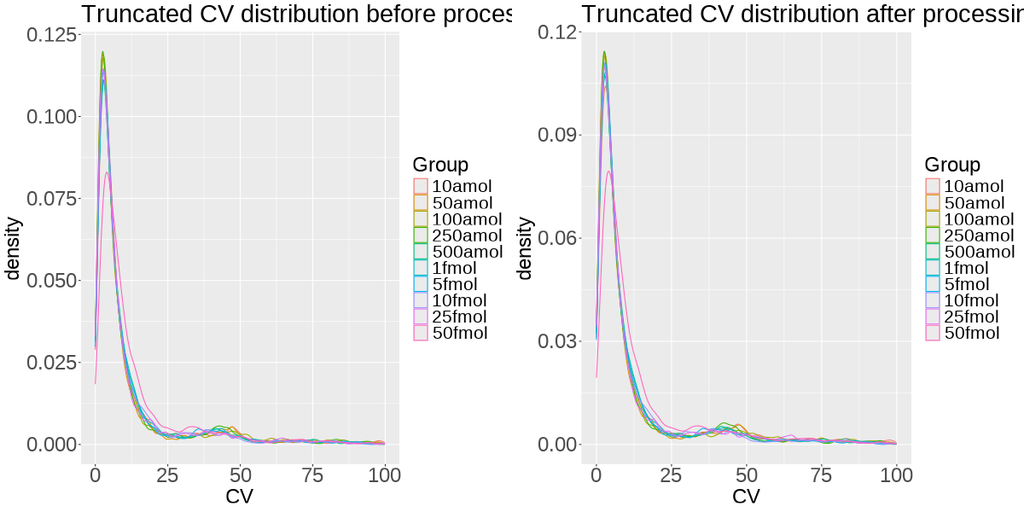

Save figure

Heterogeneity of biological error

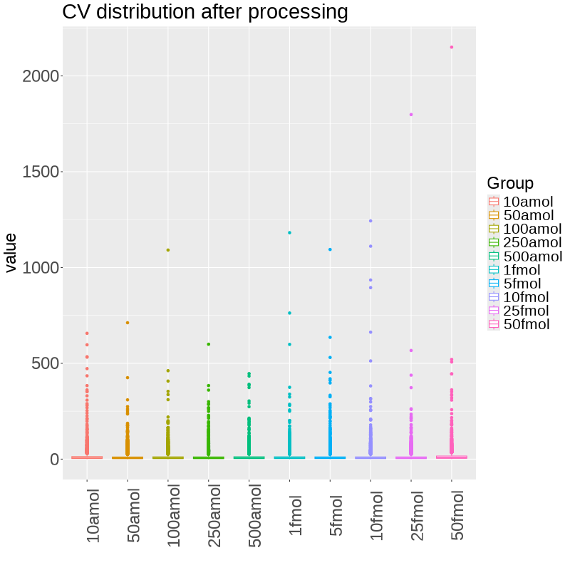

Save figure

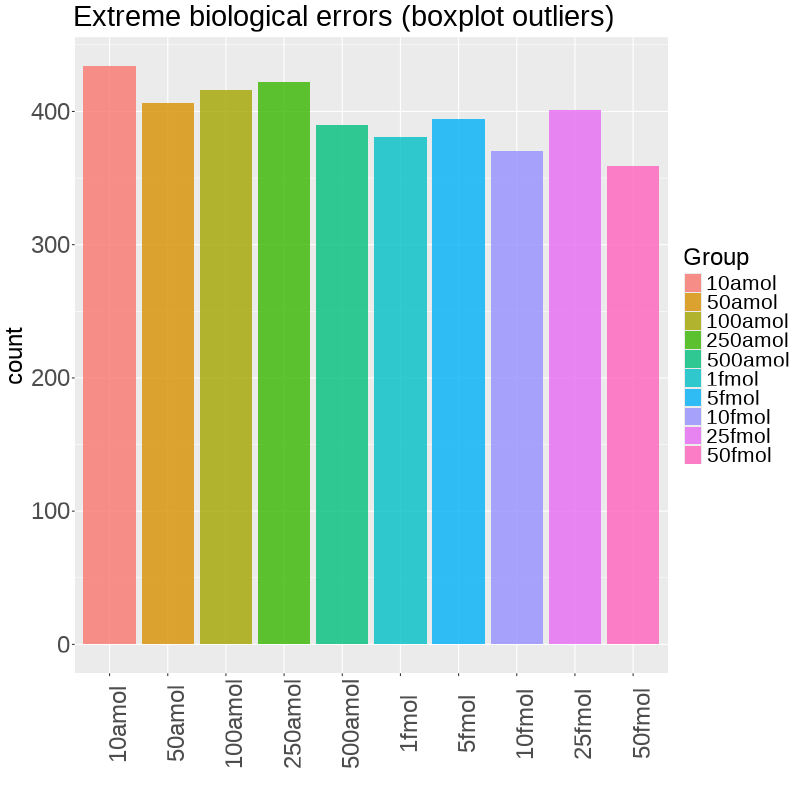

Save figure

# **Differential analysis**

50fmol/25fmol

Filtered Proteins

| Filter | Value | Value_Percentage |
| --- | --- | --- |
| No specific peptides | 14 | 0.5 |
| Less than 50% observations in at least one group | 10 | 0.3 |
| Less than 2 files identified by MS/MS | 379 | 12.9 |
| Proteins kept for analysis | 2533 | 86.3 |

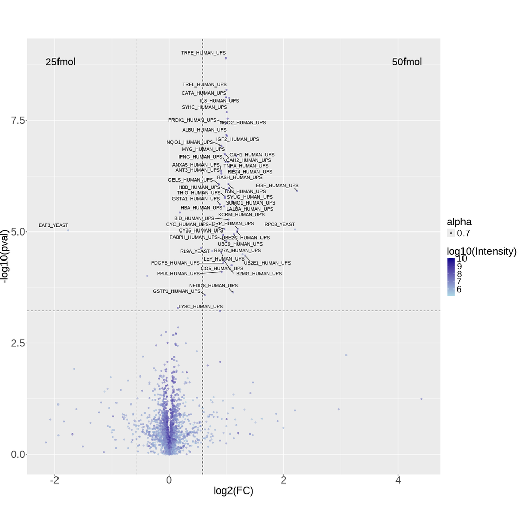

Save figure

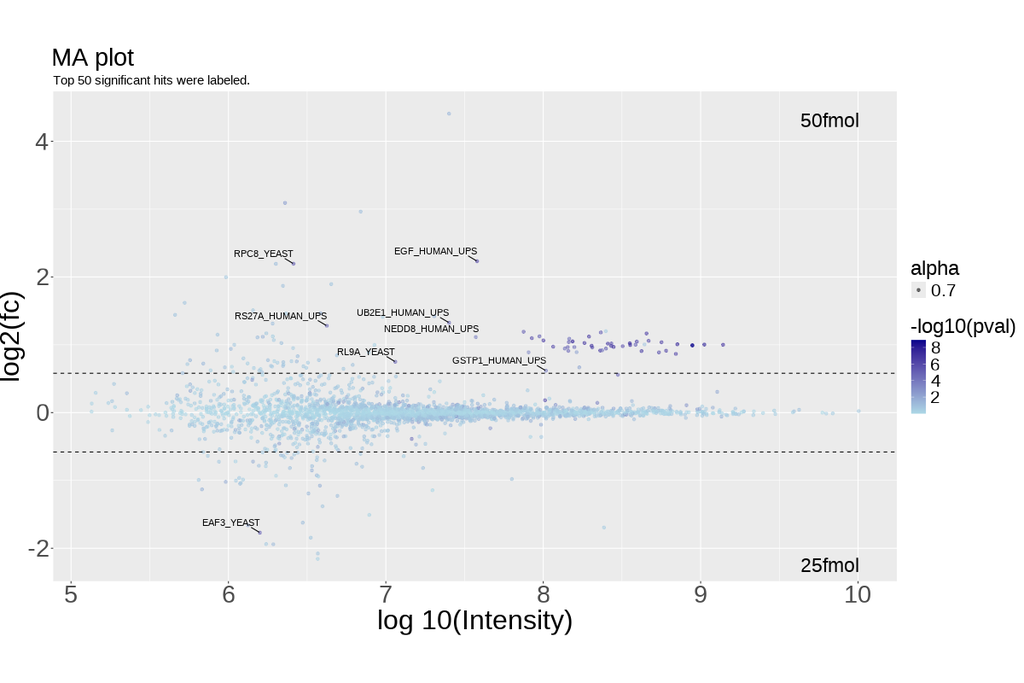

Save figure

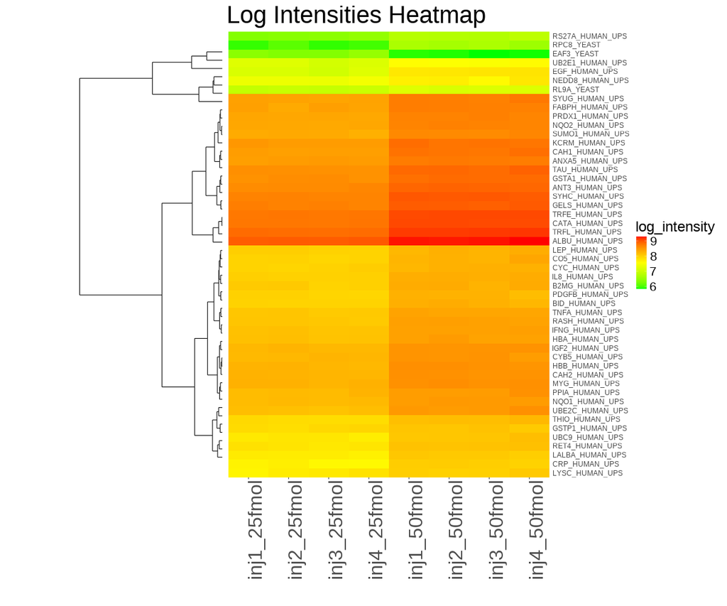

Save figure

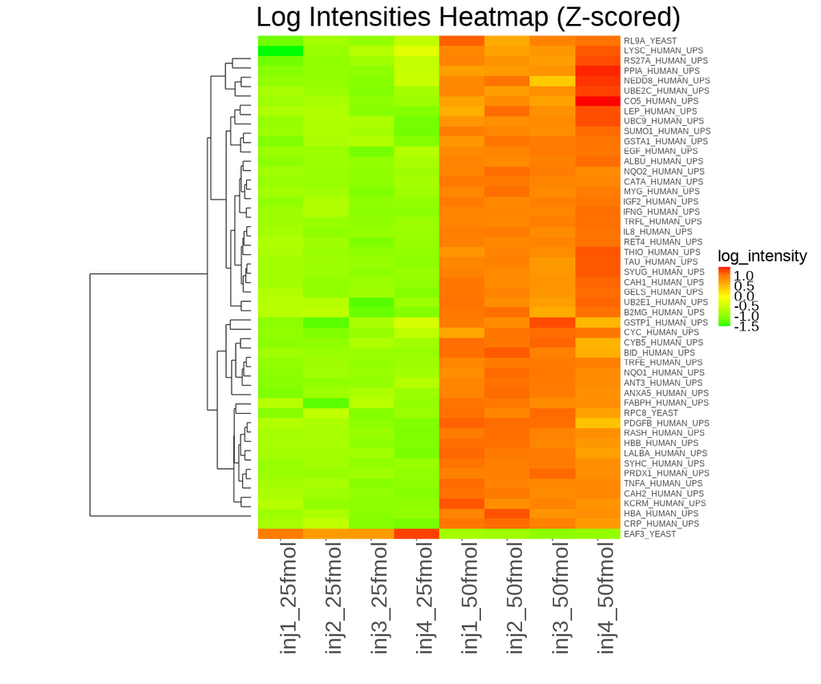

Save figure

| Id | Accession | Label | inj1_25fmol_mean | inj2_25fmol_mean | inj3_25fmol_mean | inj4_25fmol_mean | inj1_50fmol_mean | inj2_50fmol_mean | inj3_50fmol_mean | inj4_50fmol_mean | fc | pval | qval |
| --- | --- | --- | --- | --- | --- | --- | --- | --- | --- | --- | --- | --- | --- |
| 123542 | RS27A_HUMAN_UPS | RS27A_HUMAN_UPS | 2.14539e+06 | 2.35042e+06 | 2.49480e+06 | 2.84824e+06 | 5.91974e+06 | 5.63835e+06 | 5.40963e+06 | 6.92115e+06 | 2.42801e+00 | 3.23353e-05 | 1.86149e-03 |
| 123544 | GELS_HUMAN_UPS | GELS_HUMAN_UPS | 5.20230e+08 | 4.84744e+08 | 4.99236e+08 | 4.69417e+08 | 9.14968e+08 | 8.92085e+08 | 8.54008e+08 | 9.34061e+08 | 1.82158e+00 | 8.58121e-07 | 1.03506e-04 |
| 123637 | KCRM_HUMAN_UPS | KCRM_HUMAN_UPS | 3.28393e+08 | 2.96799e+08 | 2.92895e+08 | 2.93659e+08 | 6.96773e+08 | 6.04446e+08 | 6.26159e+08 | 5.96884e+08 | 2.08316e+00 | 3.21907e-06 | 2.71797e-04 |
| 123660 | PDGFB_HUMAN_UPS | PDGFB_HUMAN_UPS | 9.94688e+07 | 9.77180e+07 | 8.98750e+07 | 8.78968e+07 | 1.92530e+08 | 1.88713e+08 | 1.88351e+08 | 1.52032e+08 | 1.92455e+00 | 5.02282e-05 | 2.70698e-03 |
| 123758 | ANT3_HUMAN_UPS | ANT3_HUMAN_UPS | 4.01791e+08 | 4.10430e+08 | 4.12847e+08 | 4.49584e+08 | 7.76794e+08 | 8.13233e+08 | 7.94900e+08 | 7.66275e+08 | 1.88171e+00 | 4.91573e-07 | 6.55344e-05 |
| 123788 | HBB_HUMAN_UPS | HBB_HUMAN_UPS | 1.86665e+08 | 1.87457e+08 | 1.74125e+08 | 1.68546e+08 | 3.78329e+08 | 3.76643e+08 | 3.56926e+08 | 3.40671e+08 | 2.02648e+00 | 1.15857e-06 | 1.27594e-04 |
| 123876 | FABPH_HUMAN_UPS | FABPH_HUMAN_UPS | 2.75175e+08 | 2.21761e+08 | 2.79956e+08 | 2.50652e+08 | 5.32634e+08 | 5.24209e+08 | 5.02771e+08 | 4.96724e+08 | 2.00122e+00 | 1.63035e-05 | 1.03242e-03 |
| 123891 | CAH2_HUMAN_UPS | CAH2_HUMAN_UPS | 1.90818e+08 | 1.83359e+08 | 1.77998e+08 | 1.72765e+08 | 3.70516e+08 | 3.63017e+08 | 3.48253e+08 | 3.51670e+08 | 1.97735e+00 | 1.83982e-07 | 3.84466e-05 |
| 123916 | CRP_HUMAN_UPS | CRP_HUMAN_UPS | 4.75732e+07 | 5.14928e+07 | 4.23864e+07 | 4.13359e+07 | 1.07206e+08 | 1.10578e+08 | 1.03993e+08 | 9.58854e+07 | 2.28496e+00 | 8.70250e-06 | 6.49967e-04 |
| 123921 | SYHC_HUMAN_UPS | SYHC_HUMAN_UPS | 4.71443e+08 | 4.86541e+08 | 4.62471e+08 | 4.69899e+08 | 9.77546e+08 | 9.50134e+08 | 9.59587e+08 | 9.11667e+08 | 2.00964e+00 | 2.08832e-08 | 1.05794e-05 |

[output cut: 40 more lines]

50fmol/500amol

Filtered Proteins

| Filter | Value | Value_Percentage |
| --- | --- | --- |
| No specific peptides | 14 | 0.5 |
| Less than 50% observations in at least one group | 11 | 0.4 |
| Less than 2 files identified by MS/MS | 316 | 10.8 |
| Proteins kept for analysis | 2595 | 88.4 |

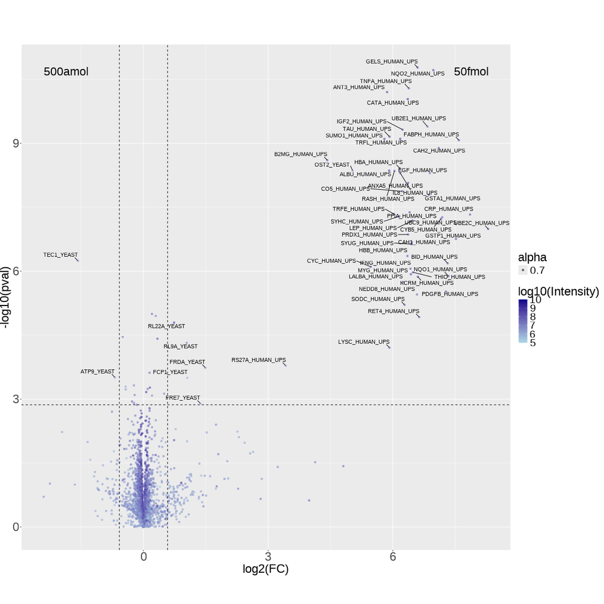

Save figure

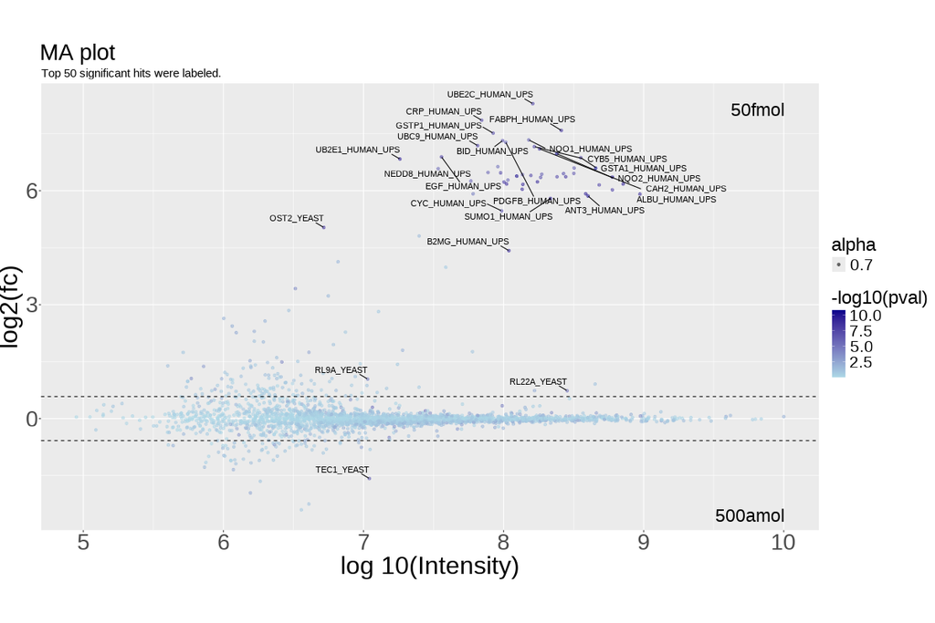

Save figure

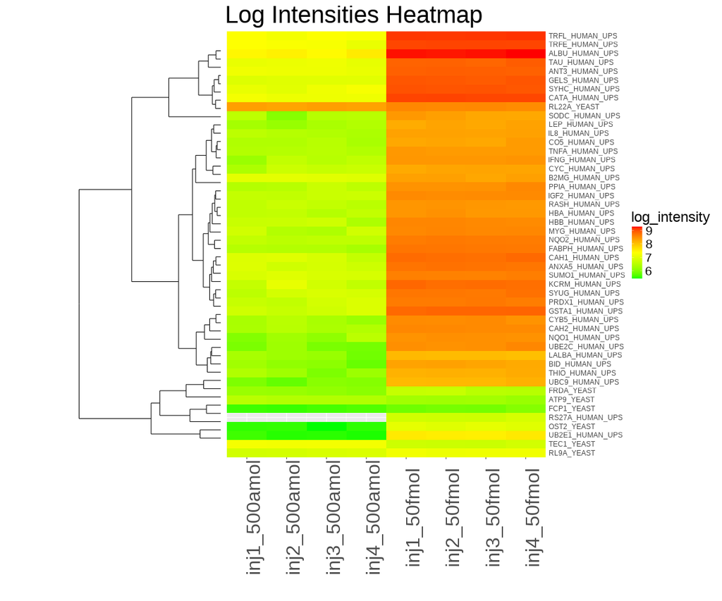

Save figure

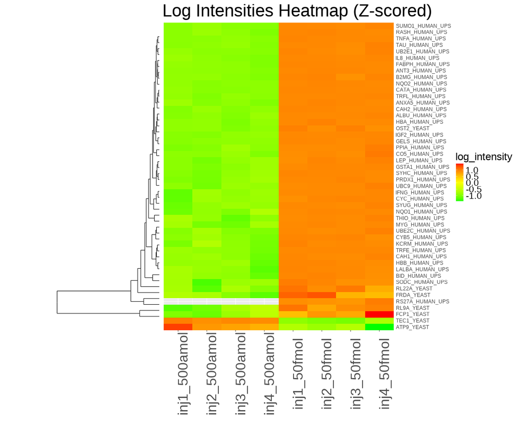

Save figure

| Id | Accession | Label | inj1_500amol_mean | inj3_500amol_mean | inj2_500amol_mean | inj4_500amol_mean | inj1_50fmol_mean | inj2_50fmol_mean | inj3_50fmol_mean | inj4_50fmol_mean | fc | pval | qval |
| --- | --- | --- | --- | --- | --- | --- | --- | --- | --- | --- | --- | --- | --- |
| 123542 | RS27A_HUMAN_UPS | RS27A_HUMAN_UPS |  |  |  |  | 5.91974e+06 | 5.63835e+06 | 5.40963e+06 | 6.92115e+06 | 1.07242e+01 | 1.64936e-04 | 7.64300e-03 |
| 123544 | GELS_HUMAN_UPS | GELS_HUMAN_UPS | 8.51945e+06 | 9.63045e+06 | 9.30008e+06 | 9.76406e+06 | 9.14968e+08 | 8.92085e+08 | 8.54008e+08 | 9.34061e+08 | 9.66066e+01 | 1.66651e-11 | 2.48947e-08 |
| 123637 | KCRM_HUMAN_UPS | KCRM_HUMAN_UPS | 4.34490e+06 | 6.07658e+06 | 1.16070e+07 | 3.99652e+06 | 6.96773e+08 | 6.04446e+08 | 6.26159e+08 | 5.96884e+08 | 9.69938e+01 | 1.34368e-06 | 8.10898e-05 |
| 123758 | ANT3_HUMAN_UPS | ANT3_HUMAN_UPS | 1.44074e+07 | 1.36847e+07 | 1.39867e+07 | 1.21184e+07 | 7.76794e+08 | 8.13233e+08 | 7.94900e+08 | 7.66275e+08 | 5.81432e+01 | 6.28725e-11 | 4.07885e-08 |
| 123788 | HBB_HUMAN_UPS | HBB_HUMAN_UPS | 4.77230e+06 | 5.64787e+06 | 4.97328e+06 | 2.41046e+06 | 3.78329e+08 | 3.76643e+08 | 3.56926e+08 | 3.40671e+08 | 8.15870e+01 | 4.39401e-07 | 3.25785e-05 |
| 123876 | FABPH_HUMAN_UPS | FABPH_HUMAN_UPS | 3.04214e+06 | 2.71044e+06 | 2.82288e+06 | 2.11656e+06 | 5.32634e+08 | 5.24209e+08 | 5.02771e+08 | 4.96724e+08 | 1.92325e+02 | 8.44003e-10 | 1.99108e-07 |
| 123891 | CAH2_HUMAN_UPS | CAH2_HUMAN_UPS | 2.23890e+06 | 2.30535e+06 | 3.14865e+06 | 2.73263e+06 | 3.70516e+08 | 3.63017e+08 | 3.48253e+08 | 3.51670e+08 | 1.37495e+02 | 1.29139e-09 | 2.79262e-07 |
| 123921 | SYHC_HUMAN_UPS | SYHC_HUMAN_UPS | 1.19088e+07 | 1.40171e+07 | 9.66042e+06 | 1.77916e+07 | 9.77546e+08 | 9.50134e+08 | 9.59587e+08 | 9.11667e+08 | 7.11705e+01 | 5.13670e-08 | 5.12683e-06 |
| 123928 | RL22A_YEAST | RL22A_YEAST | 2.23246e+08 | 2.25118e+08 | 1.96120e+08 | 2.09024e+08 | 3.69573e+08 | 3.53465e+08 | 3.66530e+08 | 3.31066e+08 | 1.66446e+00 | 1.59945e-05 | 8.13840e-04 |
| 123956 | TEC1_YEAST | TEC1_YEAST | 1.71507e+07 | 1.65403e+07 | 1.60440e+07 | 1.62912e+07 | 5.51866e+06 | 5.23922e+06 | 5.05932e+06 | 6.28846e+06 | 3.34801e-01 | 5.69438e-07 | 4.10470e-05 |

[output cut: 38 more lines]